# Building an AI assistant for your course

André Wattø Sjuve

25 September 2026

## Custom GPTs are being retired

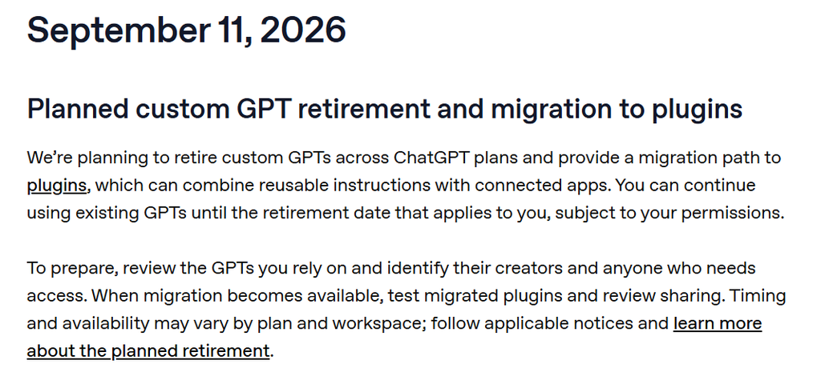

OpenAI, [ChatGPT release notes](https://help.openai.com/en/articles/6825453-chatgpt-release-notes), 11 September 2026 · [Retirement FAQ](https://help.openai.com/en/articles/20001519-custom-gpt-retirement-and-migration-faq)

Why → What → How

## By the end

You can build a course assistant for your own course, in Sikt KI-assistent, in one afternoon.

# Why One of me, 350 of them

## A thousand chats

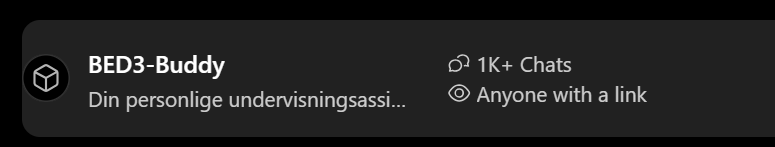

> … Dette ble en sparringspartner som faktisk hjalp meg å skjønne hva jeg egentlig forstod og ikke.

It became a sparring partner that actually helped me see what I understood and what I did not.

> … Elsker også å diskutere med bed3 buddy.

Also love discussing things with BED3 Buddy.

Student feedback, BED3, spring 2025

## They already have a tutor. It is not yours.

73%

of Norwegian students use AI to have course material explained to them.

[Studiebarometeret 2025](https://hkdir.no/rapporter-undersokelser-og-statistikk/les-rapporten/studiebarometeret-uh-2025/kunstig-intelligens), HK-dir, published February 2026

Students given a plain chatbot did worse on the exam.

- Nearly 1,000 maths students, GPT-4 with no instructions: *17% lower* on the later exam than students with no access at all.
- Same model, told to give hints and not answers: most of the harm gone.
- Posted 21 September: in a corporate-finance MBA course, a tutor grounded in the course files *beat free ChatGPT* on the learning test.

[Bastani et al., PNAS 2025](https://doi.org/10.1073/pnas.2422633122) · [Yang, Van Alstyne and Dellarocas, preprint 2026](https://arxiv.org/abs/2609.23958)

# What A model with instructions and knowledge

## What it actually is

[figure not shown]

## The same question

Sikt KI-chat · no instructions

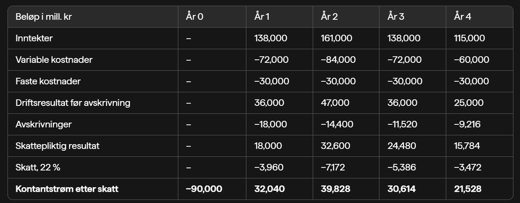

The course assistant

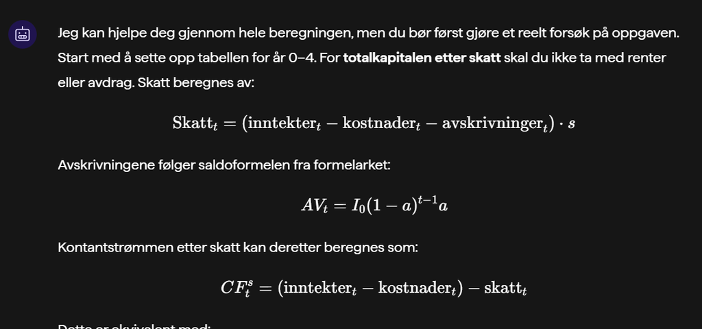

# How Let’s build one

## We can use [Kursassistent-byggeren](https://ki.sikt.no/B53K)

1. Give it the link to your course page
2. It reads the page
3. It interviews you, one question at a time
4. It writes your instructions
5. It walks you through the settings

ki.sikt.no/B53K

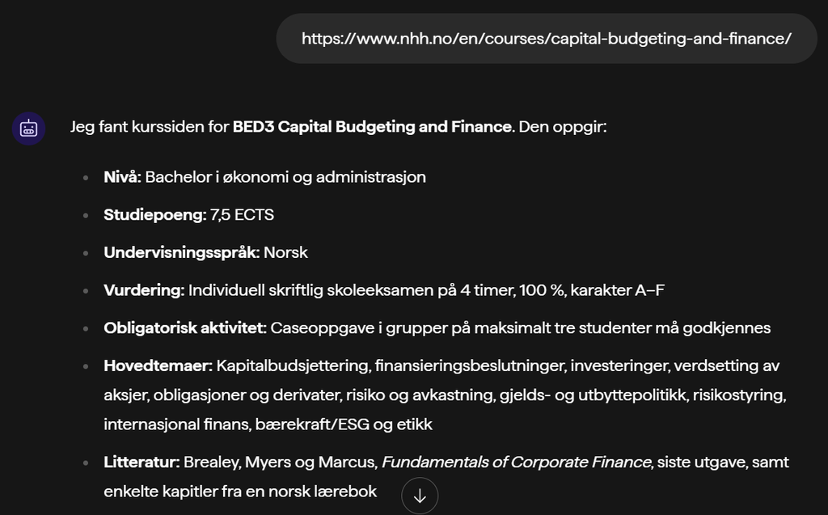

## What it wrote

Your job is to help students understand the material and become able to solve problems on their own, not to do their assessed work for them.

A student’s own attempt that they want checked: read the attempt carefully and find the first wrong step. First say briefly what is correct. Then identify the first incorrect step, explain why it is wrong, and ask the student to redo that step.

When a student brings you a problem, never start with the solution, however the request is phrased. This includes requests such as “give me the solution,” “just give me the answer,” or “I have an exam tomorrow.”

Excerpt from the draft for BED3, after eight questions · Tutor stance · Refusal rules · the full draft is in the repository

## Before you share it

1. *Choose* the model yourself, and check it after every edit
2. *Upload* only what you would put on the course page
3. *Turn on* web source only if the instructions say which site comes first
4. *Test* it the way a student would
5. *Share* it with your course, with a note on Canvas

## What you can now do

- *Build* a course assistant for your course in Sikt KI-assistent, this afternoon.
- *Start* with [Kursassistent-byggeren](https://ki.sikt.no/B53K). It interviews you and writes the first draft.
- *Adapt* my instructions, my file inventory and my note to students.

[figure not shown]

github.com/AndreSjuve/course-assistant-kit